# OP-JEGJ230017 1121..1144

Converted from PDF `Celli-LongTermMassLayoffs-2023-JEG.pdf` · 24 pages · anchors: page `#pN`, block `#pN-bK`

Page 1

## The long-term effects of mass layoffs: do local economies (ever) recover?

Viviana Celli , Augusto Cerqua †, and Guido Pellegrini

Department of Social Sciences and Economics, Sapienza University of Rome, Piazzale Aldo Moro 5, 00185 Rome, Italy †Correspondence to: augusto.cerqua@uniroma1.it

#### Abstract

This article investigates the long-term reaction of local labor markets (LLMs) to a mass layoff in a manufacturing plant. We adopt a non-parametric generalization of the difference-in-differences estimator expressly developed for time-series cross-sectional data and a new comprehensive dataset. Our results suggest that, on average, a mass layoff abruptly decreases industry employment by 22%; this negative impact is persistent even 9 years later. The shock has a negative and statistically significant effect only on the same industry of the affected LLM, while the rest of the local economy is, at most, mildly negatively affected. These findings depend on the initial level of development and call for the policymakers’ intervention to design efficient employment policies aimed at reducing the long-lasting social costs of a mass layoff at least for the less developed and less dynamic local economies.

Keywords: Mass layoff, local labor market, spillover effects, causal inference JEL classifications: H53, J60, C14 Date submitted: 4 April 2022 Editorial decision: 23 May 2023 Date Accepted: 24 May 2023

#### 1. Introduction

‘If Whirlpool closes down, Naples turns off’. With this slogan, the mayor of Naples Luigi De Magistris organized several initiatives to convince the American multinational manufacturer not to leave Naples. However, despite this desperate attempt, Whirlpool’s plant in Naples closed down on 31 October 2020, and in the following months, the collective dismissal procedure for about 350 employees started. This is only one example of how disruptive mass layoffs can be, especially in countries with struggling economies and low labor mobility, such as Italy. This scenario may have serious economic and social consequences for the area concerned, justifying the great attention paid by policymakers to contrasting these events. Instruments to support firms and workers in the area are often implemented, and dialogue tables (‘Tavoli di crisi’) between representatives of firms, workers and politicians, at central and local level, are proposed.

But is this attention really needed? If the closure of a plant was just a stage in a process of local optimal resources allocation and firms’ selection, which alternates the death of some companies with the birth or arrival of others, the concerns would be unfounded. If, on the other hand, the effects on the economy of the area persist in the long-run, with the creation of negative externalities, generating further losses of jobs, production and income, the need for public intervention would be more urgent. The limited empirical evidence available is mixed. Jofre-Monseny and Sa´nchez-Vidal (2018) and vom Berge and

# The Author(s) (2023). Published by Oxford University Press. All rights reserved. For permissions, please email: journals.permissions@oup.com

Journal of Economic Geography (2023) 23, 1121–1144 https://doi.org/10.1093/jeg/lbad012 Advance Access Publication 16 June 2023

Page 2

Schmillen (2022) find that, for each job directly lost in a mass layoff, only about 0.7 jobs are actually lost in the local affected industry; conversely Gathmann et al. (2020, 428) suggest that a mass layoff in the manufacturing sector might ‘not only harm workers in that plant but create a domino effect on the region as a whole, thereby multiplying job losses’. In addition, the long-term effects of a mass layoff have been basically unexplored, because of the shortage of coherent data over a long time span and challenging identification issues.

We add to this nascent literature by investigating the local long-term impact of a large manufacturing plant closure/downsizing on the employment of the same industry in which the mass layoff materializes. In addition, we investigate whether the mass layoff impacted the rest of the manufacturing sector, the non-tradable sector and other relevant outcome variables such as wages, income and total factor productivity (TFP). Our dataset is based on administrative time-series cross-sectional (TSCS) data on all 610 Italian local labor markets (LLMs) covering the period from 2004 to 2020, thus including the Great Recession. In order to have ‘enough’ time periods before and after the mass layoff to investigate the long-term impact, we consider for treatment mass layoffs which occurred between 2008 and 2011 in the main analysis, investigating the effects up to 9 years after the mass layoff. To tackle the complex identification problem of separating the effects of the mass layoff from other factors that may interplay with the affected area or sector, we have adopted the non-parametric generalization of the difference-in-differences (DiD) estimator for TSCS data proposed by Imai et al. (2021). We match each LLM experiencing a mass layoff to LLMs that have a very similar history in terms of industrial, economic, territorial and demographic pre-treatment characteristics. We also investigate the heterogeneity of the effect to check whether the impact depends on the stage of economic development.

Our contribution to the literature is threefold. First, our study contributes to the literature on the effects of mass layoffs on local economies. Differently from the aforementioned studies, our analysis focuses on the long-term effects of a mass layoff on the affected LLM, which are estimated simultaneously and coherently with the short-term ones, on the same sample of treated and untreated LLMs and using the same econometric model. As in vom Berge and Schmillen (2022), our estimates refer to a recent period, thus incorporating any structural changes related to the Great Recession. Second, our work presents an overall evaluation of the effects of a mass layoff on different dimensions of analysis. The long-term impact mainly depends on how the LLM reacts with respect to the net balance for employed and unemployed, replacement of production factors and the ability to attract new businesses. Therefore, our analysis considers the impact of a mass layoff on aspects other than employment, such as TFP, wages, per capita income and the number of local units in the affected industry. Third, the article contributes to the analysis of the consequences of a shock in the LLM regarding the local economic context (Pinch and Mason, 1991; Bailey et al., 2012; Hane-Weijman et al., 2018). The extent of the effects may vary in the presence of strong or weak labor markets, as mobility and absorption capacity can differ (Bartik, 2015; Bertheau et al., 2023). Here, an average measure of the effects may be of little use with respect to the variability of the labor market. To address this issue, we investigate the potentially heterogeneous impact of a mass layoff by the ex-ante economic development of the affected LLM.

We find that, on average, a mass layoff abruptly decreases industry employment by 22% and that this negative impact is persistent even 9 years after the mass layoff, with a peak of 33% in the 6th year. The effect on the other outcome variables is less pronounced and statistically not significant. Mass layoffs have a negligible impact on the rest

1122 Celli et al.

Page 3

of the manufacturing, with a multiplier close to 0. Concerning the non-tradable sector, the impact is marginal and statistically significant only one year after the shock. Differently, the TFP grows slightly in the first few years, whereas the blue- and white-collar wages slightly decrease. At the same time, while per capita income is basically not affected, the number of local units increases at the end of the period. Thus, a shock in the tradable sector has a negative, statistically significant and persistent effect only on the same industry of the LLM. Moreover, we find that this impact gets larger over time in the least developed LLMs. This demonstrates how Italian LLMs are not flexible to shocks with low dynamic adjustments, especially when the mass layoff hits areas with high unemployment rates. Our conclusion is that, in economies characterized by limited geographic mobility of the workers and low utilization of the labor force, the policymakers’ intervention is important to design efficient employment policies, especially at a time of economic crisis.

This article is structured as follows. Section 2 sets out our conceptual framework and presents the previous literature. Section 3 describes the construction of the data set and the empirical methodology. Section 4 provides the empirical estimates, in terms of employment and other variables, the analysis by sector, the evaluation of the heterogeneity of the impacts and several robustness checks. Finally, Section 5 discusses the implications of our results and draws some policy suggestions.

#### 2. Conceptual framework and previous literature

A central issue in recent crises is the link between layoffs and re-employment and the extent to which regions can absorb the redundant workforce (Hansen et al., 2021). However, there is no consensus among economists and policymakers on the direction or the extent of the impact.

From a theoretical point of view, when a labor market is characterized by perfect mobility across and between regions of capital and labor (Barro and Sala-i-Martin, 1995), any shock that moves the labor market from its equilibrium state automatically activates compensating adjustments that bring it back to equilibrium. A redundant workforce will be reabsorbed and spatial disparities will be reduced as the economy moves toward an optimal spatial equilibrium in the long-run (Martin and Sunley, 1998).

Nevertheless, neo-classical assumptions are hard to make in practice, even at the local level. Factor mobility is less than perfect (Armstrong and Taylor, 2000), wages may not be fully flexible, and access to and availability of capital is markedly uneven geographically (Mason and Harrison, 1999). Moreover, although relatively underdeveloped regions could offer low-wage labor, this is likely to be offset by agglomeration economies which encourage capital and labor flows from lagging to developed regions (Martin and Sunley, 1998). A negative shock, then, may trigger a divergence process in the regions affected, causing a hysteretic downward shift in a regional economy’s growth path. As shown in Martin (2012), this could happen when a negative shock destroys a significant proportion of a region’s productive capacity and jobs. In this case, even if output and employment growth resume after the shock, there would be a permanent loss in productivity compared with the pre-shock position. Thus, closures involve a wide variety of factors and processes across a range of levels that ‘interact in complex ways depending upon the specific situation’, with a heterogeneous long-term impact on local economies (Walker, 1992, 56). Given the lack of theoretical consensus on the long-term consequences of a mass layoff

Long-term effects of mass layoffs 1123

Page 4

on an LLM, the identification of such effects appears to be basically an empirical question.

The previous empirical literature has confirmed that the local effects of a mass layoff are clearly heterogeneous, depending on many factors, which contribute to the formation of sizable production externalities and spillovers (Greenstone et al., 2010): input–output linkages, labor market interactions and the quality of job matches, agglomeration and knowledge spillovers and consumption demand (Gathmann et al., 2020). The effects of local economic shocks are also heterogeneous across regions: they might depend on the labor market composition (Pinch and Mason, 1991), the urban–rural divide (Grimes and Young, 2011) and the thickness of the LLMs (Neffke et al., 2018). Overall, the empirical literature provides evidence that negative economic shocks weigh more heavily on peripheral and rural areas and on mono-industrial regions with a lower range of institutions (Amin and Thrift, 1995), suggesting that the effect of job displacement also depends on the local economy’s industrial mix.

Despite these difficulties in isolating the effects, the reaction of the LLM to a mass layoff, in the short- and long-run, is a key element to understanding its consequences, which may occur directly, such as the loss of jobs and the decline of the affected industrial sector, or indirectly, such as the reorganization of production chain relationships, the erosion of shared knowledge or the decline in consumer demand. However, only a few studies evaluate the effects of mass layoffs on local economies<sup>1</sup> and they concern above all the short-term impact of plant closures/downsizing. Jofre-Monseny and Sa´nchez-Vidal (2018) estimate the net industry employment effects of large manufacturing plant closures in Spain before the onset of the Great Recession. They find that when a large plant closes down because of relocation abroad, for each job directly lost in the plant closure, only between 0.6 and 0.7 jobs are actually lost in the local affected industry. Gathmann et al. (2020) use administrative data on firms and workers in Germany from 1975 to 2008 to quantify the spillover effects of mass layoffs. They find sizable and persistent negative spillover effects in terms of employment on the regional economy. However, their estimates suggest a relatively small negative impact for the workers affected. Holm et al. (2017) analyze what happens to laid-off workers when large companies close down, investigating if redundant skills are destroyed or reallocated. They show how the result depends on industry structure and urbanization. In particular, they find that getting a job in a skillrelated industry or moving to a spinoff firm leads to skill reallocation. Vom Berge and Schmillen (2022) analyze the net impact of mass layoffs on local employment in German establishments. They find that mass layoff events have significant short-term effects on local employment. They also find that over a quarter of the employment loss is absorbed by employment gains within the same municipality. These studies can be considered part of a broader literature that evaluates the (positive or negative) local multiplier effect of manufacturing employment. Moretti (2010) finds that each additional job in manufacturing in a given American city creates 1.6 jobs in the tertiary sector in the same city,<sup>2</sup> with a multiplier that varies across industries. Similar local multiplier estimates are found by Moretti and Thulin (2013) for Sweden, Faggio and Overman (2014) for the UK, Van Dijk (2017) for the USA and Cerqua and Pellegrini (2020) for Italy.

1 Here, we are referring to the overall analysis of the effects, and not that relating to specific cases of plant closures, for which the literature is much broader. 2 These effects are even larger for skilled jobs, generating 2.5 jobs in the tertiary sector every additional skilled job in the tradable sector.

1124 Celli et al.

Page 5

Lastly, we consider the studies concerned with the long-term effects of sizable layoffs on wages or the participation rate, even if they are not directly focused on the impact of mass layoffs on local economies. Displaced workers might experience earnings losses beyond a period of unemployment following their job losses for several reasons: (i) workers possessing skills that were especially suited to their old positions are likely to be less productive, at least initially, in their subsequent jobs; (ii) workers losing jobs that paid wage premiums are likely to earn less if their subsequent jobs pay standard wages and (iii) displaced workers’ long-term earnings will be lower if, in their previous jobs, they had accepted wages below their level of productivity in return for higher earnings later in their careers (Jacobson et al., 1993). Von Wachter et al. (2011) studied the long-term cost of job displacements due to layoffs or plant closures using large administrative earnings data sets from several US states, estimating that displacements during the early 1980s led to large and persistent earnings losses that last over 20 years. They find large immediate losses in annual earnings of 30%. After 15–20 years, these losses are still about 20%. Jacobson et al. (1993) find that high-tenure workers incur large losses when they separate from distressed firms and there are larger losses among workers displaced from very large firms, when the workers are displaced in regions that have depressed rates of employment growth, whereas for manufacturing workers’ earnings losses depend crucially on whether they get new jobs in the manufacturing sector. The results from Kodrzycki (2007) go in the same direction and find that, one decade later, permanently displaced workers were still earning between 11% and 17% less per year than recalled workers with comparable pre-layoff skills and experience.

The recent literature has also focused on the sources of such persistent effects of job loss on incomes and wages, considering the role of firm and industry wage differentials and specific skills (e.g., Lachowska et al., 2020; Schmieder et al., 2022; Bertheau et al., 2023), and the impact of labor market conditions at the time of displacement (Davis and von Wachter, 2011; Schmieder et al., 2022). Lachowska et al. (2020) estimate the magnitudes of reduced earnings and wages of workers displaced during the Great Recession, using linked employer–employee panel data from Washington State. The results show that 5 years after displacement, only about 30% of lost earnings were due to reduced work hours, whereas about 70% were due to lower hourly wage rates. Loss of specific worker– employer matches explains more than half of the wage losses. A different result is presented by Schmieder et al. (2022) who study what determines displaced workers’ earnings and wage losses over the business cycle using three decades of social security data of a sample of male workers from West Germany. Displaced workers suffer reductions in annual earnings of about 15% lasting at least 15 years. Reduction in wage premiums explains the large part of the level and the cyclicality in wage losses. These reductions are larger in recessions. A recent paper by Bertheau et al. (2023) presents an interesting international comparison of the consequences of losing a job using a harmonized research design applied to seven matched employer–employee datasets. The results show a strong heterogeneity in the labor market consequences of losing a job across Europe: Southern European workers are less likely to find employment following displacement. Moreover, displaced workers from Southern European countries have a higher probability of being permanently displaced from the labor market following displacement. Transitions from better to worse paying firms explain a large share of the observed wage losses for all countries, in line with Schmieder et al. (2022).

The effects of earning losses associated with job displacement and the impact of labor market conditions at the time of displacement on it are presented in Davis and von

Long-term effects of mass layoffs 1125

Page 6

Wachter (2011). Using longitudinal Social Security records in USA from 1974 to 2008, they indicate that displaced workers suffer reductions in the present value of future annual earnings by 12% in an average year. However, the losses rise steeply with the unemployment rate in the year of displacement. A similar result is in Schmieder et al. (2022), that suggest that displaced workers experience reductions in establishment size and establishment wage premiums at job loss, and that these reductions are larger in recessions.

Mass layoffs have also an impact on the long-run population growth in the LLM. For instance, Foote et al. (2019), who examine the relationship between mass layoffs and the long-run size of the local labor force, show how out-migration accounts for more than half of the labor force reduction over the past two decades. They also find that labor force non-participation increased during the Great Recession, accounting for most of the local labor force exits following a mass layoff, and after 2007 it replaced out-migration as the predominant channel of labor force adjustment.

#### 3. Data and methodology

3.1. Data Our unit of analysis is the LLM. LLMs are sub-regional geographical areas where the bulk of the labor force lives and works, and where establishments can find the largest amount of the labor force necessary to occupy the jobs offered. LLMs are defined on a functional basis, the key criterion being the proportion of commuters who cross the LLM boundary on their way to work.<sup>3</sup> Italy counts 610 LLMs.

3 The criteria used to determine Italian LLMs are similar to those used to define Metropolitan Statistical Areas in the USA or Travel to Work Areas in the UK. 4 The Statistical Register of Active Enterprises (ASIA) archive is produced by the Italian National Institute of Statistics (ISTAT) and covers the universe of firms and employees of industry and services in each LLM. Some preliminary analyses have been carried out by the authors at the ISTAT’s Laboratorio per l’Analisi dei Dati ELEmentari (ADELE) in Rome. 5 In Italy, when a large plant has to face a financial and/or a patrimonial crisis, the Ministry of Economic Development (MISE) intervenes in the management of the negative productive and employment effects with the support of the Ministry of Labor, trade unions and local institutions. The action of the MISE and other public bodies is oriented toward safeguarding the productive assets of all companies and is focused on encouraging the continuation of activities and adopting all necessary measures to safeguard employment levels and protect workers. The MISE manages the dialogue tables (‘Tavoli di crisi’) until the transfer of the productive activity, or the achievement of an agreement that does not require any monitoring (e.g., the reorganization or stabilization of the activities, or the cessation of the activities). If the dialogue tables result in a reduction of business activity, in a transformation of the activity or in the cessation of the activity itself, the company can proceed with mass layoffs. The collective dismissal procedure must be initiated in collaboration with a trade union, which will attempt to avoid dismissal by means of another agreement or other alternative solutions to collective dismissal. 6 In a subsequent short-term analysis, we will consider as treated 57 LLMs experiencing a mass layoff over the period 2008–2015.

1126 Celli et al.

Page 7

This means that the timing of mass layoffs is staggered and we should use an evaluation strategy able to take this feature into account (see Section 3.2). The treatment dummy Dij;t is equal to 1 in the ith LLM and the jth industry from the time corresponding to the mass layoff (t ¼ T) onwards, with t that goes from T 4 to T þ 9. Hence, treatment is an absorbing state, so that once an LLM-industry is treated, it remains treated for the remainder of the panel.

We have data at the LLM level on the number of employees for each manufacturing sector (two-digit NACE classification), the tertiary sector and other economic and demographic variables from 2004 to 2020. The main dependent variable is the number of employees. In particular, for the main analysis we look at the change that occurred in the number of employees in the industry affected by the shock, using the pre-mass layoff year (T 1) as base year. The focus on the number of employees at the

Table 1. Treated cases for the long-term analysis

Firm Sector (two-digit NACE)

Closure/ mass layoff

Year Municipality LLM Job losses (local unit)

Job losses

(industry)

Coca-Cola

and Peroni

11 Closure 2009 Bari Bari 109 þ 110 227

Olimpias S.P.A. 13 Closure 2011 Grumolo Delle Abbadesse

Vicenza 110 135

Playtex 14 Closure 2010 Pomezia Pomezia 159 177 Golden Lady 14 Closure 2011 Gissi Vasto 386 389 Golden Lady 14 Closure 2011 Faenza Faenza 346 356 Ferrania 20 Mass layoff 2008 Cairo Montenotte Cairo Montenotte

112 143

Montefibre 20 Closure 2008 Ottana Macomer 139 154 Montefibre 20 Closure 2011 Venezia Venezia 247 299 Pfizer 21 Closure 2009 Latina Latina 152 126 MAS Italia 22 Closure 2011 Pistoia Pistoia 104 141 Manuli rubber 22 Mass layoff 2008 Ascoli Piceno Ascoli Piceno 129 206 Arcelor Mittal 24 Mass layoff 2010 Piombino Piombino 205 145 Renopress 24 Closure 2011 Budrio Bologna 93 119 SAT 25 Almost closure 2009 Aci Sant’Antonio Catania 137 312 Jabil Circuit 26 Closure 2008 San Marco Evangelista

Caserta 500 434

Imit 26 Mass layoff 2010 Castelletto Sopra Ticino

Borgomanero 160 205

Electrolux 27 Mass layoff 2008 Porcia Pordenone 502 374 Antonio Merloni 27 Mass layoff 2008 Nocera Umbra Gualdo Tadino 501 447 Electrolux 27 Mass layoff 2009 Susegana Conegliano 194 337 Electrolux 27 Closure 2010 Scandicci Firenze 281 430 Nexans 27 Mass layoff 2011 Latina Latina 110 98 Acc Compressors 28 Closure 2009 Rovigo Rovigo 144 176 CNH—gruppo Fiat 28 Closure 2010 Imola Imola 130 158 Berco 28 Mass layoff 2010 Copparo Copparo 119 156 Eaton 28 Closure 2011 Massa Massa 303 631

Notes: Coca-Cola and Peroni closed down in the LLM of Bari in the same year. As they belong to the same industry, namely ‘manufacture of beverages’, we count these closures as a single treated case.

Long-term effects of mass layoffs 1127

Page 8

industry-level requires setting up the database at the LLM-industry level. The main dependent variable is:

Then, we also check what happens to the number of employees in the rest of the manufacturing sector, to verify whether the other industries not directly affected by the shock also record some changes in the output variable. We also run the analysis using as dependent variable the change in the number of employees in the tertiary sector, the per capita income, the change in the number of local units in the affected industry, the weekly earnings of native white-collar workers and blue-collar workers and the TFP.<sup>7</sup> The pre-treatment values of these variables will be used as control variables in our empirical analyses, together with population and employment and unemployment rates. Table 2 presents summary statistics for all these variables, while Table A1 in Supplementary Appendix A provides their detailed description. We refine the sample used for the empirical analysis by excluding cases with large drops or large increases in the affected industry in the year before the treatment, cases in which the mass layoff is reabsorbed in the year after the negative shock and the four largest LLMs (Turin, Rome, Naples and Milan). Indeed, these LLMs are too vast to allow detection of any impact of a mass layoff. In addition, we have dropped the LLM-industry observations experiencing a mass layoff in the pre-treatment period.<sup>8</sup> Lastly, taking into account our definition of mass layoffs, we have dropped from

Table 2. Descriptive statistics

[output not shown]

NOTE: table converted from PDF layout to HTML text; cell boundaries are reconstructed. See PDF if exact alignment matters.

Notes: This table considers all LLMs and all years from 2004 to 2020. The time period is shorter due to lack of data for the following variables: 2004–2017 for TFP, 2006–2020 for employment and unemployment rate and 2007–2018 for the wage variables. The source of each variable is reported in Table A1 in the Supplementary Appendix.

7 Weekly earnings of native white-collar workers and blue-collar workers have been made available from the Italian social security administration (INPS) archive, which covers the universe of Italian employer–employee matches in the private sector, while TFP data come from the work of Locatelli et al. (2019) and Albanese et al. (2020). 8 We have found 11 mass layoffs in the manufacturing sector between 2004 and 2007.

1128 Celli et al.

Page 9

the control group the LLM-industry observations for which the number of employees was less than 100 in the year before the mass layoff.

3.2. Methodology

The key econometric challenge in analyzing the effects of a mass layoff is that LLMs experiencing such a shock may systematically differ from unaffected LLMs.

To identify proper counterfactuals for the affected LLM, we use a recent evaluation technique proposed by Imai et al. (2021), which consists of a non-parametric generalization of the DiD estimator expressly developed for TSCS data. In the proposed approach, we first select for each treated LLM-industry a set of control LLMs-industry that did not experience a mass layoff and belong to the same geographical area (North, Centre or South). We, then, refine this matched set, Mij, by using the Mahalanobis distance matching, which assigns a positive weight to the five control units within Mij more similar to the treated unit in terms of pre-treatment trends of the outcome and control covariates. In particular, we use as pre-treatment covariates the lagged values of the number of employees in the industry, the number of employees in the manufacturing sector without the industry affected, the total number of employees, the per capita income, the employment rate, the unemployment rate, the population level, the share of graduates, TFP and the average size of manufacturing firms. Then, for each treated LLM-industry, we estimate the counterfactual outcome using the weighted average of the control units in the refined matched set. Finally, we use the DiD estimator to calculate the treatment effect for each treated LLM-industry and then average it across all treated observations to get the average treatment effects among treated (ATT).

An important step in this procedure is the choice of a non-negative integer F as the number of leads, which represents the outcome of interest measured at F time periods after the administration of treatment, where F ¼ 0 represents the contemporaneous effect. We selected F ¼ 9 implying the treatment effect on the outcome 9 years after the mass layoff materialized. We select another non-negative integer L as the number of lags to adjust for. The choice must take into account the bias-variance trade-off: while a greater value improves the credibility of the unconfoundedness assumption, it also reduces the efficiency of the resulting estimates by reducing the number of potential matches. We chose L ¼ 4. Because the choice of L is arbitrary, we test the sensitivity of the empirical results to this choice in Section 4.1.2.

We define the ATT as:

Long-term effects of mass layoffs 1129

Page 10

layoff in the pre-treatment period up to L. In our case, d(9, 4) represents the average causal effect of a plant closure/downsizing on the outcome, 9 years after the treatment, while assuming that the potential outcome depends on the treatment history up to 4 years earlier.

We then compute the DiD estimate of the ATT for each treated observation and then average it across all treated observations. Formally:

Standard errors are computed using a block-bootstrap procedure. The non-parametric generalization of the DiD estimator is based on three assumptions.

Assumption 1. Absence of the carryover effect. This implies that the potential outcome for the LLM-industry ij at time T þ F does not depend on the previous treatment status of the same LLM-industry after L time periods. This implies that we allow for the possibility that past treatments affect future outcomes up to L years.

Assumption 2. Absence of an interference effect. The potential outcome for LLM-industry ij at time T þ F does not depend on the treatment status of other units.

Assumption 3. Parallel trend assumption after conditioning on the treatment, outcome and covariate histories.

Where Zij;t is a vector of observed time-varying confounders for LLM-industry ij at year t. Therefore, the conditioning set includes the treatment history, the lagged outcomes and the covariate history. Choosing a relatively large value of L (in our case L ¼ 4) increases the credibility of a limited carryover effect<sup>9</sup> and the parallel trend assumptions, while using data at the LLM level mitigates concerns about the validity of the no-interference assumption.

This set of assumptions is arguably milder than those used by the most common methodologies adopted to analyze TSCS data, such as the two-way fixed effects estimator (TWFE), dynamic panel models, matching methods and the DiD estimator (Imai et al.,

9 The validity of this assumption is further strengthened by the removal from the control group of the LLMindustry observation that experienced a mass layoff in the years 2004–2007.

1130 Celli et al.

Page 11

2021).<sup>10</sup> Furthermore, differently from the above-mentioned estimators, the non-parametric generalization of the DiD estimator is ideal for our evaluation study as it also works well in situations with a small number of treated units. Last, this approach, differently from other recently proposed estimators (e.g., the DiD with multiple time periods estimators proposed by de Chaisemartin and D’Haultfoeuille (2020) and Callaway and Sant’Anna (2021)), explicitly tests for pre-treatment trend differences in all covariates and does not rely on parametric assumptions.

#### 4. Empirical analysis

In this section, we estimate the effects of a large manufacturing plant closure/downsizing on local employment. We focus primarily on the employment changes that occurred up to 9 years after the negative event in the industry affected by the shock and in the rest of economy and then we analyze the potential heterogeneity of these effects. We then test the sensitivity of our results using different robustness checks.

Before presenting the estimates, it is important to verify whether Assumption 3 is met in order to guarantee the robustness of the empirical analysis. To this end, the nonparametric generalization of the DiD estimator allows examination of the covariate balancing between treated and matched control observations. This enables the investigation of whether the treated and matched control observations are comparable with respect to observed confounders (Imai et al., 2021). The covariate balance plot is reported in Figure 1. The black line represents the balance of the main lagged outcome, whereas gray lines show the balance of the other covariates. It clearly emerges that the level of imbalance remains stable across the 4 pre-treatment years and fully within the (1, 1) range of the standard deviation. It is important to notice that we use the same control variables for all empirical analyses, meaning that the covariate balance plot presented in Figure 1 is the same for all the analyses presented below. In addition, as the level of imbalance for the lagged values of our primary dependent variable, that is, the change that occurred in the number of employees in the industry affected by the shock, stays relatively constant over the entire pre-treatment period, this demonstrates that the parallel trend assumption after conditioning on the treatment, outcome and covariate histories is plausible.

4.1. Main estimates

We start by estimating the impact of a manufacturing plant closure/downsizing on the employment level of the affected industry and that of the rest of the local economy up to 9 years after the shock. We then check the robustness of these estimates and investigate

10 Recent literature has shown that estimates from TWFE models in which the timing of policy changes are staggered over time can be biased when the treatment effect varies over time (see, among others, Callaway and Sant’Anna, 2021; de Chaisemartin and D’Haultfœuille, 2020; Imai and Kim, 2021). Indeed, in case of staggered adoption, TWFE estimators make both ‘clean’ comparisons between treated and not-yet-treated units, as well as ‘forbidden’ comparisons between units who are both already-treated (de Chaisemartin and D’Haultfœuille, 2022). In addition, the estimation of the ATT by TWFE corresponds to a weighted average of causal effects for each treatment group (treatment groups are defined on the basis of the year of treatment) in which the weights are not proportional to the number of treatments and may even be negative in some cases (De Chaisemartin and D’Haultfœuille, 2020). Differently from the TWFE estimator, the non-parametric generalization of the DiD estimator proposed by Imai et al. (2021) does not suffer from these drawbacks.

Long-term effects of mass layoffs 1131

Page 12

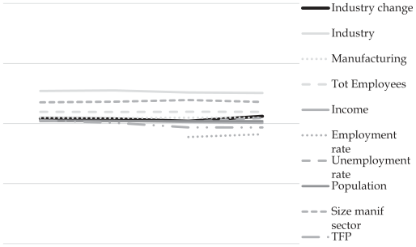

NOTE: figure/graphic rendered as an image from the PDF; its content is not machine-readable text. Caption (if any) follows as the next block.

the impact on aspects other than employment, such as TFP, wages, per capita income and the number of local units in the affected industry.

4.1.1. Analysis by sector In this section, we run the analysis for the main outcomes of interest. We begin by analyzing what happens to the number of employees in the industry affected by the shock.

Figure 2A shows that the industry affected by the shock suffers severe and persistent negative consequences. With respect to the number of employees in the matched control LLMs, the employment level is about 22% smaller in the year of the mass layoff and 33% smaller in the 6th year after the shock. All the estimates are statistically significant at the 1% level. The negative impact is not reabsorbed over time, as it persists even 9 years after the mass layoff.<sup>11</sup>

Figure 1. Covariate balancing. Note: The y-axis refers to the standardized mean differences between treated and untreated (matched) LLM-industry observations.

11 To better isolate the spillover effect of the mass layoff on the affected LLM-industry, we have created an alternative dependent variable defined as follows:

where Layoffij is the number of workers who lost the job in the mass layoff, and Layoffij > 0 only in the posttreatment period of treated LLM-industry observations. Figure A1 in Supplementary Appendix A reports the estimates based on this alternative dependent variable. In this analysis, a zero coefficient is consistent with no indirect employment effects of the mass layoffs. This figure shows a negative coefficient, confirming that the negative impact persists and gets larger over time, meaning that an additive negative spillover effect at the industry level might exist.

1132 Celli et al.

Page 13

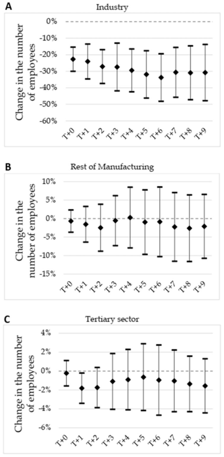

NOTE: figure/graphic rendered as an image from the PDF; its content is not machine-readable text. Caption (if any) follows as the next block.

Figure 2. Long-term analysis by (A) Industry; (B) Rest of manufacturing; (C) Tertiary sector. Notes: The figures show the point estimates as well as the confidence intervals at the 5% level of significance. The Y-axis shows the dependent variable, whereas the X-axis shows the post-treatment time periods considered.

Long-term effects of mass layoffs 1133

Page 14

We also investigate what happens in the other manufacturing industries not directly affected by the mass layoff, using as outcome variable the percentage of jobs lost in the rest of the manufacturing sector. As shown in Figure 2B, mass layoffs do not spillover on the other manufacturing industries. The effect is negligible and not statistically significant over the whole period. This means that the shock affecting one industry does not transmit to the other manufacturing industries of the same LLM but, at the same time, it demonstrates that the loss of workers in one industry is not reabsorbed by other manufacturing industries. We then run a further analysis to explore what happens to the tertiary sector once the shock materializes. As shown in Figure 2C, the effect is generally negative but statistically not significant for the entire period under analysis, except for a small negative impact one year after the mass layoff. This means that, in our analysis, a mass layoff in a manufacturing industry has, at most, a mild negative impact on the tertiary sector.

In Supplementary Appendix B, we complement these findings by further investigating what happens to the dismissed workers after the mass layoff in terms of geographical mobility and re-employment opportunities. To this end, we use the same evaluation strategy and data on the number of individuals in and out of the labor force in the affected LLM, the number of workers in the affected industry and in the rest of manufacturing industries in adjacent LLMs. As reported in Supplementary Appendix B, these additional estimates support the hypotheses that the mass layoff might have slightly reduced the number of workers in the affected LLM and that some dismissed workers might have moved to jobs in manufacturing available in adjacent LLMs.<sup>12</sup>

4.1.2. Robustness checks We test the sensitivity of our results to a broad set of robustness checks and summarize the results of interest in Table 3. First, we check the sensitivity of our estimates to the choice of the number of lags (L). In the main analysis we have set L ¼ 4, while in the first two rows of each panel of Table 3, we present the estimates obtained by setting L ¼ 3 and L ¼ 2.<sup>13</sup> Then, we change the dimension of the matched set, using 10 and 3 neighbors instead of 5. We also test the sensitivity of the main analysis using different matching and weighting methods to refine the matched set of control units. In the first case, we use propensity score matching (PSM) (Rosenbaum and Rubin, 1983), while in the second case, we use the inverse propensity score weighting (IPW) method (Hirano et al., 2003). All these estimates are in line with those reported in the main analysis: the shock has a negative and statistically significant impact after 9 years for the industry affected by the shock in all the robustness checks, while in the rest of manufacturing the effect is in no case statistically significant. Concerning the non-tradable sector, the robustness checks are in line with the main analysis, with a statistically significant negative impact at T þ 1. The only differences concern 2 years after the shock, when the effect becomes statistically significant in some of the tests, and when using only three neighbors, with a negative impact that is never statistically significant. In addition, we test the sensitivity of our method by

1134 Celli et al.

Page 15

Table 3. Robustness checks

Panel A—Industry

Years after treatment

T T þ 1 T þ 2 T þ 3 T þ 4 T þ 5 T þ 6 T þ 7 T þ 8 T þ 9

(3.73) (5.38) (5.22) (7.36) (6.61) (7.31) (7.33) (7.70) (8.30) (8.68)

(3.46) (5.14) (5.11) (7.27) (6.60) (7.30) (7.37) (7.89) (8.33) (8.92)

(3.49) (5.10) (4.90) (7.42) (6.40) (7.03) (7.12) (7.44) (7.94) (8.34)

(3.44) (3.61) (4.07) (6.13) (5.41) (6.05) (6.08) (6.79) (6.85) (7.01)

(3.65) (7.83) (7.09) (9.60) (8.52) (9.13) (9.18) (9.18) (10.14) (10.30)

(3.59) (5.37) (7.01) (8.53) (8.10) (8.56) (8.59) (8.92) (9.36) (10.01)

(3.39) (3.04) (3.60) (5.77) (4.66) (5.68) (5.51) (6.06) (6.14) (6.41)

(3.37) (2.85) (3.36) (5.17) (3.60) (4.65) (4.29) (4.57) (4.74) (5.01)

de Chaisemartin and

(3.01) (3.08) (4.75) (6.43) (6.86) (8.82) (9.20) (10.95) (12.27) (13.75)

(continued)

Long-term effects of mass layoffs 1135

Page 16

Table 3. Continued

[output not shown]

NOTE: table converted from PDF layout to HTML text; cell boundaries are reconstructed. See PDF if exact alignment matters.

(continued)

1136 Celli et al.

Page 17

Table 3. Continued

Panel C– Tertiary

de Chaisemartin & D’Haultfoeuille

Notes: All estimates are expressed in percentages. The estimates concerning the non-parametric generalization of the DiD estimator are based on the R package ‘PanelMatch’,

while we have used the Stata commands ‘csdid’ and ‘did_multiplegt’ for implementing the Callaway and Sant’Anna (2021) and the de Chaisemartin and D’Haultfoeuille

(2020) estimators, respectively. The estimator proposed by de Chaisemartin and D’Haultfoeuille (2020) has been estimated by adding LLM-industry-specific trends.

***p < 0.01, **p < 0.05, *p < 0.1.

Long-term effects of mass layoffs 1137

Page 18

adopting two alternative estimators: the DiD with multiple time periods estimators developed by Callaway and Sant’Anna (2021) and De Chaisemartin and D’Haultfœuille (2020).<sup>14</sup> Likewise the non-parametric generalization of the DiD estimator, for these estimators the key assumption is that the parallel trend assumption holds after conditioning on observed covariates. Small differences emerge when looking at the point estimates reported in Table 3 but, overall, they resemble our main estimates.

We then run a placebo test in which we used as ‘fake’ treatment cases 12 LLMsindustry, with manufacturing firms that managed to avoid mass layoffs by striking a deal with the Italian government for new buyers or received public subsidies (see Table A2 in Supplementary Appendix A). As shown in panel A of Table 3, the effect is statistically non-significant for the entire period after the ‘fake’ treatment when considering the industry affected by the shock. Likewise, negligible effects also emerge when considering the rest of the manufacturing and the tertiary sector. These results allow us to strengthen the robustness of our main estimates: the point estimates of this falsification test are close to zero and show no discernible impact whatsoever. Furthermore, the placebo estimates highlight that government intervention is not only crucial for manufacturing firms on the verge of a mass layoff, but also for the affected industry in the local economy.

One of the main novelties of our research is given by the fact that we run a long-term analysis. The cost of this advantage is that we have only 25 treated cases. To check the robustness of our estimates, we run also a short-term analysis using 5 years after the treatment. In this case, our treated sample gets larger as it is formed by 57 treated cases (see Table A3 in Supplementary Appendix A), that is, large manufacturing firms which experienced a mass layoff between 2008 and 2015. Figure A2 in Supplementary Appendix A presents the covariate balancing, while Supplementary Table A4 reports the short-term estimates, which are highly consistent with what we found for the long-term analysis. In particular, the loss in the employment level of the affected industry is confirmed, with an increasing trend of up to 33% 5 years after the shock. Not statistically significant effects are estimated in the rest of the manufacturing sector, while for the tertiary sector, the effect is statistically significant at the 10% level only in the first 2 years after the mass layoffs.

4.1.3. Mass layoff impact on other outcome variables

To have a more comprehensive picture of what happens in an LLM after a mass layoff, we run the analysis using alternative outcome variables: TFP, the log of per capita income, the change in the number of local units in the affected industry, the log of weekly earnings of native white-collar workers and blue-collar workers.<sup>15</sup> As shown in Table 4, all estimates are not statistically significant, however, it is possible to identify some trends. For example, the TFP seems to grow in the first few years after the shock and then to settle at near zero values. Differently, the number of local units in the affected industry slightly increases in the long-run, whereas the blue- and white-collar wages slightly

14 The main differences between these parametric estimators concern the weights they place on different cohorts/ time periods and on the possibility to add or not unit-specific trends (for more details, see Roth et al., 2023). 15 Because TFP data end in 2017, we fix the leads at 6 and 2 periods for the long-term and short-term analysis, respectively, in order to have the same number of treated cases with respect to the rest of the analysis. Similarly, as data on wages are available for the period 2007–2018, we fix the leads at 7 and 3 periods for the long-term and short-term analysis, respectively.

1138 Celli et al.

Page 19

decrease. Income, instead, do not seem to be affected by the shock. These findings suggest that a mass layoff is generally not driven by the need to increase productivity or reduce specific inefficiencies but by a decrease in the production capacity in the affected area. This can occur due to a corporate decision to abandon specific markets, even in anticipation of a drop in demand, or to move to areas with lower labor costs. On the other hand, as we do not observe a substantial increase in TFP, mass layoffs are likely not linked to technological restructuring. This consideration implies that the occurrence of a mass layoff is not directly linked to the human capital of laid-off workers, which can also be of high quality.

4.2. Impact heterogeneity The timing and extent of mass layoff reabsorption can also depend on the unemployment rate of the affected LLM. To verify the potential presence of heterogeneity in the effect of a mass layoff in the tradable sector, we repeat the same analysis by splitting LLMs in three groups determined by the tertiles of the unemployment rate in 2007 (with cut-off values of 3.51% and 6.89%). This analysis allows us to analyze whether the effect changes with respect to the initial different economic situation of the treated LLMs. The estimates are reported in Table 5.

Table 4. Mass layoff impact on other outcome variables

[output not shown]

NOTE: table converted from PDF layout to HTML text; cell boundaries are reconstructed. See PDF if exact alignment matters.

Notes: The table shows the mass layoff impact on the alternative outcome variables (in the first column) up to 9 years after the layoff. Block-bootstrapped standard errors are reported in parentheses. The estimates are expressed in percentages, except for TFP. ***p < 0.01, **p < 0.05, *p < 0.1.

Long-term effects of mass layoffs 1139

Page 20

Table 5. Effect heterogeneity by sector

[output not shown]

NOTE: table converted from PDF layout to HTML text; cell boundaries are reconstructed. See PDF if exact alignment matters.

T T þ 1 T þ 2 T þ 3 T þ 4 T þ 5 T þ 6 T þ 7 T þ 8 T þ 9

(5.75) (5.11) (5.52) (8.77) (7.97) (10.93) (8.93) (9.71) (9.82) (9.54)

(7.48) (22.33) (18.52) (21.01) (21.30) (21.76) (21.91) (21.27) (25.16) (26.07)

Notes: The table shows the mass layoff impact for LLMs with a different initial level of unemployment rate. In particular, the tertiles’ cut-off values are 3.51% and 6.89%.

Block-bootstrapped standard errors are reported in parentheses. All estimates are expressed in percentages.

***p < 0.01, **p < 0.05, *p < 0.1.

1140 Celli et al.

Page 21

recover and do not reabsorb the lost workforce in the affected industry. Furthermore, in line with other studies (e.g., Davis and von Wachter, 2011; Schmieder et al., 2022) we find that the negative impact of a mass layoff is amplified by a low initial level of economic development or the stage of the business cycle.

We also investigate how the effect materializes for the rest of the manufacturing sector. Although the effect is always non-statistically significant, LLMs characterized by low unemployment rate show positive coefficients in absolute terms up to the 7th year. On the contrary, for the observations in the second and third tertiles, the point estimate is negative, even if statistically non-significant for the entire period.

Finally, we analyze the impact for the services sector. In this case, the effect is always negative, even if not statistically significant, except for LLMs characterized by high unemployment rates, in which the effect is positive from the 5th to the 7th year. Also in this case, anyway, the effects are close to zero for the whole period.

#### 5. Conclusion

The negative shock on a large plant opens a scenario that deserves a comprehensive and accurate analysis. Besides knowing how many workers leave the company undergoing downsizing or closure, it is crucial to grasp how the affected local economy reacts to a negative employment shock.

Shutdowns generate important questions of public policy as well as more theoretically informed analyses as researchers seek to understand how communities respond and look to unpack the implications for the functioning of contemporary labor markets (Beer et al., 2019). To this end, our study contributes to the literature on several fronts. We create a comprehensive database and use a methodology expressly developed for TSCS data to analyze Italian LLMs’ economic resilience undergoing a deep economic contraction. Furthermore, our study is the first devoted to examining the long-term effects of a mass layoff in the local economy.

The results show that a shock in the tradable sector has a negative and persistent effect on the local economy only on the industry experiencing the mass layoff, with a negative but statistically non-significant impact for the rest of the local economy. These estimates demonstrate how Italian LLMs are not very flexible to shocks, and the external multiplier is close to 0. Although we do not find strong evidence of a domino effect as Gathmann et al. (2020), there are no signs that the local economy alone can overcome the shock in socially acceptable times. Moreover, we find that this impact gets larger over time in the least developed LLMs. This result is in line with what has been highlighted in the literature, which shows wider negative effects for the weakest countries and areas (Bertheau et al., 2023). The negative impact appears to be greater in areas with slow dynamic adjustment mechanisms and responsiveness, as demonstrated by the persistent high unemployment rates in the South of Italy. For this reason, in economies characterized by limited geographic mobility of the workers and low utilization of the labor force, the policymakers’ intervention is important to design efficient employment policies, especially at a time of economic crisis. The results sustain the actions taken by national or local authorities to reduce these employment shocks and mass layoff long-lasting negative effect on the affected local economies, especially in weaker and less dynamic regions.

The pandemic has likely amplified these negative effects. On the one hand, uncertainty in the markets and reduced consumer demand has resulted in lower investment and

Long-term effects of mass layoffs 1141

Page 22

decreased labor demand, reducing the likelihood of finding other employment for dismissed workers. On the other hand, pandemic risks and administrative measures have reduced the possibility of mobility and thus of finding new jobs outside the local area. Therefore, the pandemic crisis might determine negative multipliers larger than those we have found in this study. Following these considerations, the economic crisis engendered by COVID-19 (see Cerqua and Letta, 2022) reinforces the calls for specific place-based policies aimed at contrasting the reduction of employment at the time of a severe economic crisis and supporting struggling firms as jobs might be lost forever rather than only temporarily.

#### Acknowledgements

We are grateful to the Editor Stephen Gibbons and two anonymous referees for their valuable advice. We also gratefully acknowledge helpful comments from participants at the 2019 ERSA Conference, the 2021 AISRe Conference, the 2021 NetCIEX annual meeting, the 2022 COMPIE Conference and the Sapienza DISSE and MEMOTEF seminars.

#### Supplementary material

Supplementary data for this paper are available at Journal of Economic Geography online.

#### References

Albanese, G., de Blasio, G., Locatelli, A. (2020) Does EU regional policy promote local TFP

growth? Evidence from the Italian Mezzogiorno. Papers in Regional Science, 100: 327–348. Amin, A., Thrift, N. (1995) Institutional issues for the European regions: from markets and plans to

socioeconomics and powers of association. Economy and Society, 24: 41–66. Armstrong, H., Taylor, J. (2000) Regional Economics and Policy, 3rd edn. London: Blackwell. Bailey, D., Chapain, C., de Ruyter, A. (2012) Employment outcomes and plant closure in a

post-industrial city: an analysis of the labour market status of MG Rover workers three years on. Urban Studies, 49: 1595–1612. Barro, R. J., Sala-i-Martin, X. (1995) Economic Growth. New York: McGrow Hill. Bartik, T. J. (2015) How effects of local labor demand shocks vary with the initial local unemploy-

ment rate. Growth and Change, 46: 529–557. Beer, A., Weller, S., Barnes, T., Onur, I., Ratcliffe, J., Bailey, D. (2019) The urban and regional

impacts of plant closures: new methods and perspectives. Regional Studies, Regional Science, 6: 380–394. Bertheau, A., Acabbi, E. M., Barcelo´, C., Gulyas, A., Lombardi, S., Saggio, R. (2023) The unequal

consequences of job loss across countries. American Economic Review: Insights. Available online at: https://www.aeaweb.org/articles?id=10.1257/aeri.20220006&from=f Callaway, B., Sant’Anna, P. H. C. (2021) Difference-in-differences with multiple time periods.

Journal of Econometrics, 225: 200–230. Cerqua, A., Letta, M. (2022) Local inequalities of the COVID-19 crisis. Regional Science and

Urban Economics, 92: 103752. Cerqua, A., Pellegrini, G. (2020) Local multipliers at work. Industrial and Corporate Change, 29:

959–977. Davis, S. J., von Wachter, T. M. (2011) Recessions and the costs of job loss. Brookings Papers on

Economic Activity, Economic Studies Program, 43: 1–72. de Chaisemartin, C., D’Haultfoeuille, X. (2020) Two-way fixed effects estimators with heteroge-

neous treatment effects. American Economic Review, 110: 2964–2996.

1142 Celli et al.

Page 23

de Chaisemartin, C., D’Haultfoeuille, X. (2022) Two-way fixed effects and differences-in-differences

with heterogeneous treatment effects: a survey. The Econometrics Journal (first published online: 08 June 2022). Faggio, G., Overman, H. (2014) The Effect of public sector employment on local labour markets.

Journal of Urban Economics, 79: 91–107. Foote, A., Grosz, M., Stevens, A. (2019) Locate your nearest exit: mass layoffs and local labor mar-

ket response. ILR Review, 72: 101–126. Gathmann, C., Helm, I., Scho¨nberg, U. (2020) Spillover effects of mass layoffs. Journal of the

European Economic Association, 18: 427–468. Greenstone, M., Hornbeck, R., Moretti, E. (2010) Identifying agglomeration spillovers: evidence

from winners and losers of large plant openings. Journal of Political Economy, 218: 536–598. Grimes, A., Young, G. (2011) Spatial effects of ‘mill’ closures: does distance matter? The

Australasian Journal of Regional Studies, 17: 264–299. Hansen, H. K., Lyngemark, D. H., Weatherall, D. C. (2021) Migration and employment after an eco-

nomic shock: regional characteristics and migration patterns. Regional Studies, 55: 907–920. Hane-Weijman, E., Eriksson, R. H., Henning, M. (2018) Returning to work: regional determinants

of re-employment after major redundancies. Regional Studies, 52: 768–780. Hirano, K., Imbens, G., Ridder, G. (2003) Efficient estimation of average treatment effects using the

estimated propensity score. Econometrica, 71: 1161–1189. Holm, J. R., Østergaard, C. R., Olesen, T. R. (2017) Destruction and reallocation of skills following

large company closures. Journal of Regional Science, 57: 245–265. Imai, K., Kim, I. S. (2021) On the use of two-way fixed effects regression models for causal infer-

ence with panel data. Political Analysis, 29: 405–415. Imai, K., Kim, I. S., Wang, E. (2021) Matching methods for causal inference with time-series cross-

sectional data. American Journal of Political Science (first published online: 11 December 2021). Jacobson, L. S., LaLonde, R. J., Sullivan, D. G. (1993) Earning losses of displaced workers. The

American Economic Review, 83: 685–709. Jofre-Monseny, J., Sa´nchez-Vidal, M. (2018) Big plant closures and local employment. Journal of

Economic Geography, 18: 163–186. Kodrzycki, Y. K. (2007) Using unexpected recalls to examine the long-term earnings effects of job

displacements. FRB of Boston Working Paper No. 07–2. Lachowska, M., Mas, A., Woodbury, S. A. (2020) Sources of displaced workers’ long-term earnings

losses. American Economic Review, 110: 3231–3266. Locatelli, A., Ciani, E., Pagnini, M. (2019) TFP differentials across italian macro-regions: an ana-

lysis of manufacturing corporations between 1995 and 2015. Journal of Economic Policy, 2: 209–242. Martin, R. (2012) Regional economic resilience, hysteresis and recessionary shocks. Journal of

Economic Geography, 12: 1–32. Martin, R., Sunley, P. (1998) Slow convergence? Post-neo-classical endogenous growth theory and

regional development. Economic Geography, 74: 201–227. Mason, C., Harrison, R. (1999) Financing entrepreneurship: venture capital and regional develop-

ment. In R. Martin (ed.) Money and the Space Economy, pp. 157–183. Chichester: Wiley. Moretti, E. (2010) Local multipliers. American Economic Review, 100: 373–377. Moretti, E., Thulin, P. (2013) Local multipliers and human capital in the United States and Sweden.

Industrial and Corporate Change, 22: 339–362. Neffke, F., Otto, A., Hidalgo, C. (2018) The mobility of displaced workers: how the local industry

mix affects job search. Journal of Urban Economics, 108: 124–140. Pinch, S., Mason, C. (1991) Redundancy in an expanding labour market: a case-study of displaced

workers from two manufacturing plants in Southampton. Urban Studies, 28: 735–757. Rosenbaum, P. R., Rubin, D. B. (1983) The central role of the propensity score in observational

studies for causal effects. Biometrika, 70: 41–55. Roth, J., Sant’Anna, P. H. C., Bilinski, A., Poe, J. (2023) What’s trending in difference-in-differences? A synthesis of the recent econometrics literature. Available online at: https://arxiv.org/abs/2201.01194 (version: 11 January 2023). Schmieder, J. F., von Wachter, T., Heining, J. (2022) The costs of job displacement over the busi-

ness cycle and its sources: evidence from Germany. NBER Working Paper No. 30162. http:// www.nber.org/papers/w30162

Long-term effects of mass layoffs 1143

Page 24

Van Dijk, J. J. (2017) Local employment multipliers in US cities. Journal of Economic Geography,

17: 465–487. Vom Berge, P., Schmillen, A. (2022) Effects of mass layoffs on local employment—evidence from

geo-referenced data. Journal of Economic Geography, 00: 1–31. Von Wachter, T., Song, J., Manchester, J. (2011) Long-term earnings losses due to mass layoffs during

the 1982 recession: an analysis using US administrative data from 1974 to 2004. Mimeo, UCLA. Walker, S. (1992) Branch plant closures in the West of Ireland. Irish Geography, 25: 54–66.

1144 Celli et al.